[figure not shown]

# ANOVA de duas vias no R

Fernanda Fiel Peres

08 novembro, 2021

# 1 Contextualização

# 2 Carregamento dos pacotes

```r
library(dplyr)
library(car)
library(rstatix)
library(emmeans)
library(ggplot2)
library(knitr)
library(kableExtra)
library(htmltools)
```

# 3 Leitura e visualização do banco de dados

```r
dados <- read.csv2('Banco de Dados 6.csv')
glimpse(dados)
```

```
## Rows: 48
## Columns: 4
## $ Genero   <chr> "Masculino", "Feminino", "Feminino", "Masculino", "Masculino"~
## $ Alcool   <chr> "4 Canecas", "4 Canecas", "4 Canecas", "4 Canecas", "2 Caneca~
## $ Memoria  <int> 20, 50, 55, 30, 85, 30, 30, 65, 70, 35, 80, 65, 40, 80, 75, 4~
## $ Latencia <dbl> 2.1, 5.2, 5.0, 3.8, 2.9, 3.0, 3.1, 4.2, 3.9, 2.9, 1.7, 4.0, 3~
```

```r
kable(head(dados, 10), col.names = c("Gênero", "Álcool", "Memória", "Latência")) %>%
  kable_styling(full_width = F, bootstrap_options = c("striped", "hover", "condensed", "responsive"))
```

| Gênero | Álcool | Memória | Latência |
| --- | --- | --- | --- |
| Masculino | 4 Canecas | 20 | 2.1 |
| Feminino | 4 Canecas | 50 | 5.2 |
| Feminino | 4 Canecas | 55 | 5.0 |
| Masculino | 4 Canecas | 30 | 3.8 |
| Masculino | 2 Canecas | 85 | 2.9 |
| Masculino | 4 Canecas | 30 | 3.0 |
| Masculino | 4 Canecas | 30 | 3.1 |
| Feminino | 4 Canecas | 65 | 4.2 |
| Feminino | 2 Canecas | 70 | 3.9 |
| Masculino | 4 Canecas | 35 | 2.9 |

O banco contém 48 sujeitos experimentais, sendo 24 do gênero feminino.

## 3.1 Ordenando a variável “Álcool”

Colocar as categorias em uma ordem lógica (nenhum consumo, duas canecas e quatro canecas) vai facilitar a visualização dos dados no gráfico.

```r
dados$Alcool <- factor(dados$Alcool,
                       levels = c("Nenhum",
                                  "2 Canecas",
                                  "4 Canecas"))
```

# 4 Verificação dos pressupostos do modelo

## 4.1 Normalidade

A variável dependente (“Memória”) deve apresentar distribuição aproximadamente normal dentro de cada grupo. Os grupos aqui serão formados pela combinação das duas variáveis independentes (“Gênero” e “Álcool”). A normalidade será avaliada pelo teste de Shapiro-Wilk.

```r
dados %>% group_by(Genero, Alcool) %>%
  shapiro_test(Memoria)
```

```
## # A tibble: 6 x 5
##   Genero    Alcool    variable statistic     p
##   <chr>     <fct>     <chr>        <dbl> <dbl>
## 1 Feminino  Nenhum    Memoria      0.872 0.156
## 2 Feminino  2 Canecas Memoria      0.899 0.283
## 3 Feminino  4 Canecas Memoria      0.897 0.273
## 4 Masculino Nenhum    Memoria      0.941 0.622
## 5 Masculino 2 Canecas Memoria      0.967 0.870
## 6 Masculino 4 Canecas Memoria      0.951 0.720
```

Todos os grupos apresentam distribuição normal (valores de p superiores a 0,05).

## 4.2 Ausência de *outliers*

Outro pressuposto da ANOVA é a ausência de *outliers* em todos os grupos. Isso pode ser verificado através de um gráfico do tipo boxplot.

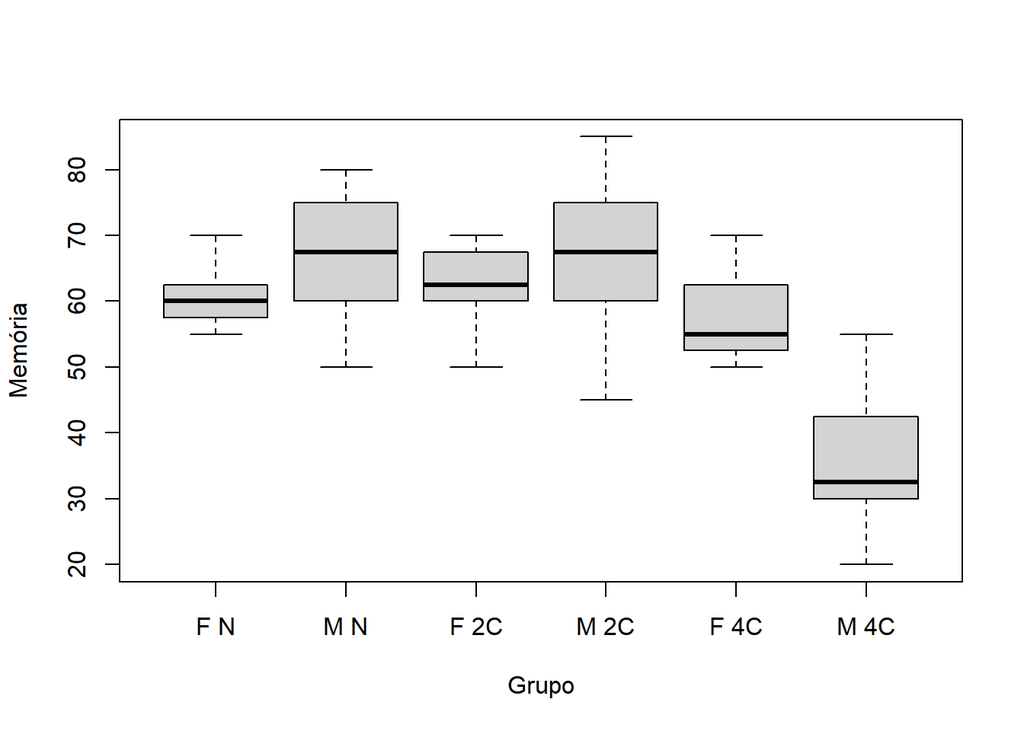

```r
boxplot(dados$Memoria ~ dados$Genero:dados$Alcool, ylab = "Memória", xlab = "Grupo",
        names = c("F N", "M N", "F 2C", "M 2C", "F 4C", "M 4C"))
```

Os gráficos mostram que não há *outliers* nos grupos analisados.

## 4.3 Homogeneidade de variâncias

Outro pressuposto da ANOVA é que os grupos apresentem variâncias homogêneas. Esse pressuposto será analisado aqui pelo teste de Levene.

```r
leveneTest(Memoria ~ Genero*Alcool, dados, center = mean)
```

```
## Levene's Test for Homogeneity of Variance (center = mean)
##       Df F value Pr(>F)
## group  5  1.5268 0.2021
##       42
```

Os resultados indicam que as variâncias são homogêneas, uma vez que o teste de Levene apresentou p superior a 0,05.

# 5 Realização do teste de ANOVA de duas vias

## 5.1 Trocando o tipo de contraste

Para essa análise, será utilizado o contraste “soma”.

```r
options(contrasts = c("contr.sum", "contr.poly"))
```

## 5.2 Criação do modelo de ANOVA

Será criado um modelo de ANOVA usando a função `aov`. O modelo escolhido é um modelo fatorial completo, que inclui os efeitos principais das variáveis independentes “Gênero” e “Álcool” bem como a interação entre elas.

```r
mod.ANOVA <- aov(Memoria ~ Genero*Alcool, dados)
```

## 5.3 Análise dos resultados do modelo

Para avaliar a significância das variáveis independentes e da sua interação, será utilizada a soma de quadrados do tipo III. Mais informações sobre os tipos de soma dos quadrados podem ser encontradas no livro “Discovering Statistics Using R” [^1].

```r
Anova(mod.ANOVA, type = 'III')
```

```
## Anova Table (Type III tests)
##
## Response: Memoria
##               Sum Sq Df   F value    Pr(>F)
## (Intercept)   163333  1 1967.0251 < 2.2e-16 ***
## Genero           169  1    2.0323    0.1614
## Alcool          3332  2   20.0654 7.649e-07 ***
## Genero:Alcool   1978  2   11.9113 7.987e-05 ***
## Residuals       3488 42
## ---
## Signif. codes:  0 '***' 0.001 '**' 0.01 '*' 0.05 '.' 0.1 ' ' 1
```

O resultado nos indica que há efeito do “Álcool” [F(2,42) = 20,07; p < 0,001] e da interação entre “Gênero” e “Álcool” [F(2,42) = 11,91; p < 0,001] sobre a memória. Dado que existe interação, os efeitos principais não devem ser interpretados. Para investigar melhor essa interação, será feito um gráfico de linhas.

## 5.4 Análise da interação entre “Gênero” e “Álcool” sobre a “Memória”

```
## No summary function supplied, defaulting to `mean_se()`
```

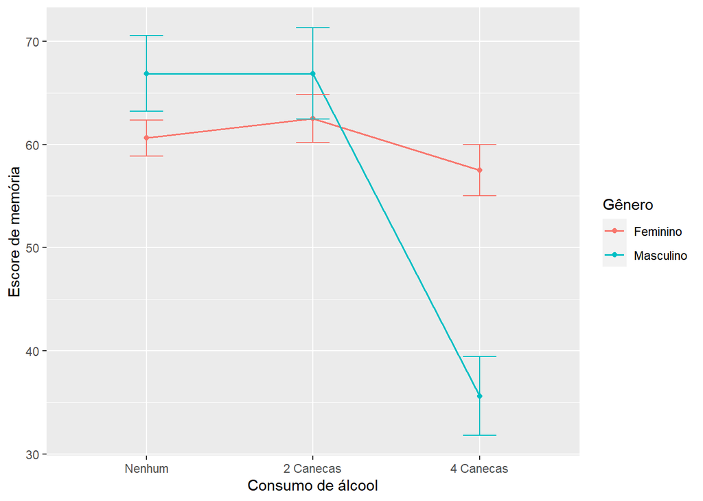

```r
ggplot(dados, aes(x = Alcool, y = Memoria, group = Genero, color = Genero)) +
  geom_line(stat = "summary", fun.data = "mean_se", size = 0.6) +
  geom_point(stat = "summary", fun.y = "mean") +
  geom_errorbar(stat = "summary", fun.data = "mean_se", width = 0.2) +
  ylab("Escore de memória") +
  xlab("Consumo de álcool") +
  labs(color = "Gênero")
```

Pelo gráfico, parece que o consumo de álcool não afetou a memória entre as mulheres. Para os homens, o padrão indica que não houve diferença entre não consumir álcool e consumir duas canecas, mas que o consumo de quatro canecas reduziu o escore de memória.  
Para verificar se essas diferenças são estatisticamente significativas, faremos comparações entre pares.

## 5.5 Comparações entre pares

```r
dados %>% group_by(Genero) %>%
  emmeans_test(Memoria ~ Alcool, p.adjust.method = "bonferroni")
```

```
## # A tibble: 6 x 10
##   Genero    term   .y.     group1 group2    df statistic       p   p.adj p.adj.signif
## * <chr>     <chr>  <chr>   <chr>  <chr>  <dbl>     <dbl>   <dbl>   <dbl> <chr>
## 1 Feminino  Alcool Memoria Nenhum 2 Can~    42 -4.12e- 1 6.83e-1 1   e+0 ns
## 2 Feminino  Alcool Memoria Nenhum 4 Can~    42  6.86e- 1 4.97e-1 1   e+0 ns
## 3 Feminino  Alcool Memoria 2 Can~ 4 Can~    42  1.10e+ 0 2.79e-1 8.36e-1 ns
## 4 Masculino Alcool Memoria Nenhum 2 Can~    42  1.95e-16 1   e+0 1   e+0 ns
## 5 Masculino Alcool Memoria Nenhum 4 Can~    42  6.86e+ 0 2.31e-8 6.94e-8 ****
## 6 Masculino Alcool Memoria 2 Can~ 4 Can~    42  6.86e+ 0 2.31e-8 6.94e-8 ****
```

```r
dados %>% group_by(Alcool) %>%
  emmeans_test(Memoria ~ Genero, p.adjust.method = "bonferroni")
```

```
## # A tibble: 3 x 10
##   Alcool    term   .y.     group1 group2    df statistic       p   p.adj p.adj.signif
## * <chr>     <chr>  <chr>   <chr>  <chr>  <dbl>     <dbl>   <dbl>   <dbl> <chr>
## 1 2 Canecas Genero Memoria Femin~ Mascu~    42    -0.960 3.42e-1 3.42e-1 ns
## 2 4 Canecas Genero Memoria Femin~ Mascu~    42     4.80  2.02e-5 2.02e-5 ****
## 3 Nenhum    Genero Memoria Femin~ Mascu~    42    -1.37  1.77e-1 1.77e-1 ns
```

Os resultados da comparação entre pares confirmam a hipótese levantada com a análise do gráfico. Há diferença entre os gêneros no escore de memória apenas na condição na qual foram consumidas quatro canecas de álcool. Para o gênero feminino, não houve efeito do álcool sobre a memória. Já para o gênero masculino, o consumo de quatro canecas diminuiu o escore de memória.

# 6 Análise descritiva

## 6.1 Médias e desvios

| Gênero | Álcool | Variável | n | Média | Desvio Padrão |
| --- | --- | --- | --- | --- | --- |
| Feminino | Nenhum | Memoria | 8 | 60.625 | 4.955 |
| Feminino | 2 Canecas | Memoria | 8 | 62.500 | 6.547 |
| Feminino | 4 Canecas | Memoria | 8 | 57.500 | 7.071 |
| Masculino | Nenhum | Memoria | 8 | 66.875 | 10.329 |
| Masculino | 2 Canecas | Memoria | 8 | 66.875 | 12.518 |
| Masculino | 4 Canecas | Memoria | 8 | 35.625 | 10.836 |

## 6.2 Gráficos de dispersão por grupo

[figure not shown]

Legenda: F = Feminino, M = Masculino, N = Nenhum consumo de álcool, 2C = Consumo de 2 canecas, 4C = Consumo de 4 Canecas.

# 7 Material de Apoio

- Visualização dos tipos de “highlights”: [Por Eran Aviv](https://eranraviv.com/syntax-highlighting-style-in-rmarkdown/)
- Visualização das opções de temas: [Por Andrew Zieffler](https://www.datadreaming.org/post/r-markdown-theme-gallery/)
- Dicas para personalização de tabelas pelo pacote `kableExtra`: [Por Hao Zhu](https://cran.r-project.org/web/packages/kableExtra/vignettes/awesome_table_in_html.html#html_only_features)
- Livro **completo** sobre RMarkdown: [R Markdown Cookbook](https://bookdown.org/yihui/rmarkdown-cookbook/)
- Material sobre RMarkdown em português: [RLadies BH](https://rladiesbh.com.br/)

# 8 Créditos

Material criado por **Fernanda F. Peres**.

- [Canal YouTube](https://youtube.com/c/FernandaPeres)
- [Página Estatística Aplicada no Instagram](https://instagram.com/estatisticaaplicada)
[^1]: Field, A. P., Miles, J., & Field, Z. (2012). Discovering statistics using R.